# Assignment 3 - Swimming pool

David Utassy

2021 02 12

## Introduction

The purpose of this writing is to document the third assignment for the course Data Analysis 3 course.

The task was to build a model to forecast 12 months ahead on swimming pool ticket transactions.

The whole analysis was written in R, and the code is available under this [GitHub repository](https://github.com/utassydv/data_analysis_prediction/tree/main/swimming_pool_forecasting). We can separate the code into three parts. I prepared the data mainly in the “swim-transactions-cleaner.R” file, then the analysis and model building is done in the “swimmingpool-predict.R” file, and the “swimmingpool-predict-doc.Rmd” file is responsible for creating this document itself.

## Data

This project is similar to the case study in CH. 13. [Data Analysis for Business, Economics, and Policy, Gabor Bekes and Gabor Kezdi](https://gabors-data-analysis.com/).

The project uses [the publicly available dataset](https://drive.google.com/drive/u/0/folders/1MTtSq7SlZwwkOt7MZSwylcpOXO75Dksv) from the city called Albuquerque (New Mexico), which was collected by POS terminals in the local swimming pools.

#### Data preparation

The original data is transaction-level ticket sales for each swimming pool in the city. In contrast with the case study in the above-mentioned book, my goal was to train my model on all the open-air pools in the city. I used the official listing of [outdoor swimming pools in the city](https://www.cabq.gov/parksandrecreation/recreation/swimming/outdoor-pools) and intuitively matched them with the location codes in the provided data.

After some explanatory data analysis, I made some modifications on the cleaner code, that the book uses to prepare data. The main aim of this data preparation is to aggregate ticket sales into a daily level.

Instead of filtering to one specific swimming pool, I filtered for all outdoor swimming pools with their Location IDs. (7 pools) I added “ADMINISTER 3’ as an included category

In the upcoming graphs, it can be clearly seen, that the daily data has a strong seasonality.

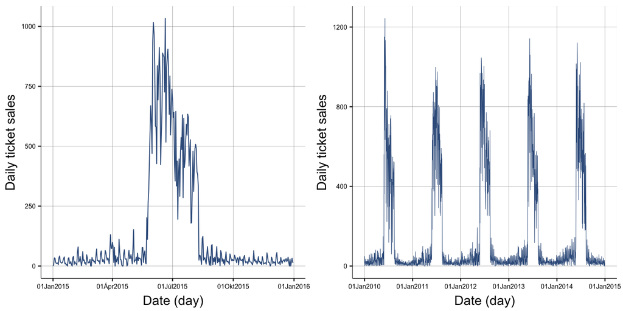

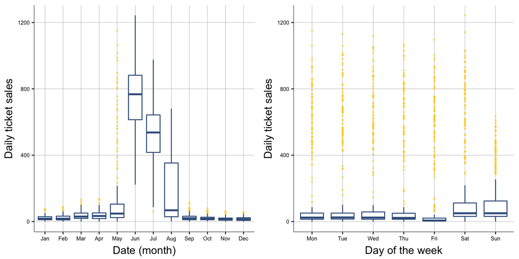

To combine day-of-week and monthly variables as interactions we have to have a better plot, that can show us the connections. I used the same heatmap as in the case study in order to observe these interactions.

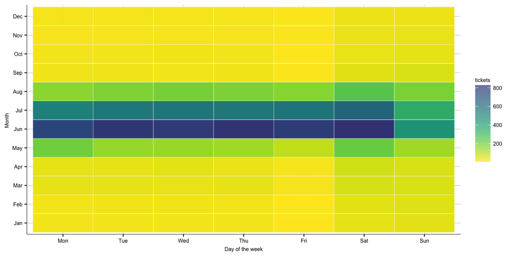

From the heatmap, we can say the same things as in the case study. I would highlight only one difference, that my data (containing all out-door pools) has a less significant drop on Fridays compared to the specific Sunport pool.

## Model Building for probability prediction

This is a long-horizon forecasting task, as I have to predict one year ahead on a daily level (365 days).

Just as in the case study on the above-mentioned book I built 7 different models:

1. linear trend + monthly seasonality
2. linear trend + monthly seasonality + days of week seasonality
3. linear trend + monthly seasonality + days of week seasonality + holidays
4. linear trend + monthly seasonality + days of week seasonality + holidays + school holiday * day-of-week
5. linear trend + monthly seasonality + days of week seasonality + holidays + interactions
6. multiplicative trend and seasonality (logs, predict log values and transform back with correction term)
7. prophet [facebook’s forecasting tool](https://facebook.github.io/prophet/docs/diagnostics.html)

As a holdout dataset, I separated 2016, which is the latest year in the dataset for final evaluation. In order to compare the models, I made 5 fold cross-validation. In the table below we can see the result of this comparison. We can see that the best models are Model 5 and the model created by Prophet. In contrast with the case study in the book, prophet outperformed my models.

|  | CV RMSE |
| --- | --- |
| Model 1 | 123.12 |
| Model 2 | 121.80 |
| Model 3 | 121.39 |
| Model 4 | 110.45 |
| Model 5 | 109.67 |
| Model 6 | 164.87 |
| Prophet | 101.80 |

To compare the two best models I compared their cross-validated RMSE monthly, which can be observed on the following plot. It is interesting to see, that Model 5 performed better in most of the months but had a huge error in December. This means that Model 5 could be a better model if we can fix it in December. Possibly we should make some modifications with winter holiday dates in order to make it better.

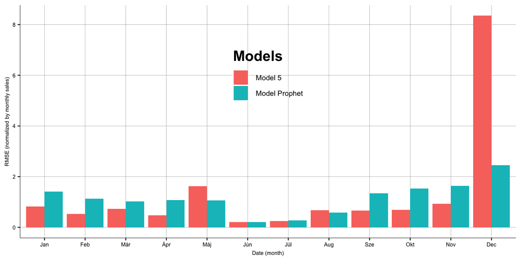

However, on average the model created by Prophet is still better, therefore I will go on with that one.

## Model Evaluation

To evaluate the best model (created by Prophet) I used the holdout dataset (2016). The RMSE turned out to be 86.2 which is a strong result compared to the CV results. (Model 5 gave 99.4)

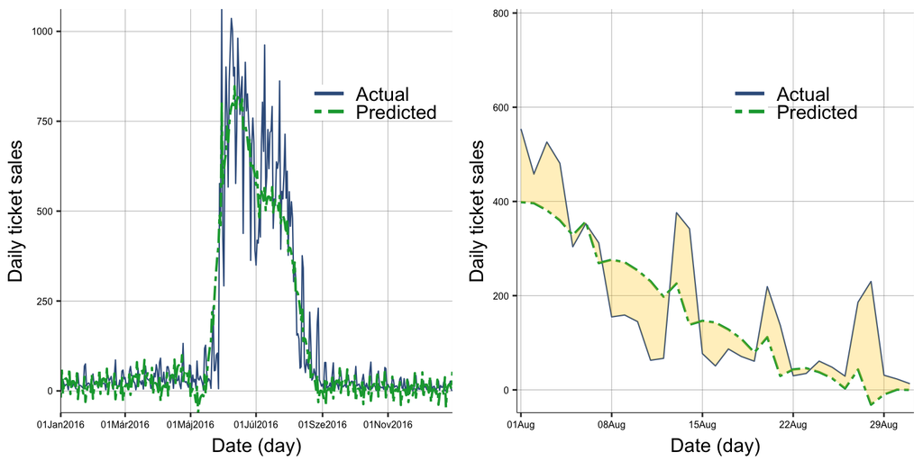

# Summary

To conclude, I would like to highlight, that my assignment using 7 standalone pools is different from the case study as its data is already less random as different pools are smoothing out the aggregated data, however, a single pool would have some specific extreme values in the data. Furthermore, it is clear, that the RMSE in my assignment is about 3 times higher than in the case study, but the quantity of the tickets sold is on average 5 times higher, which means that it is easier to predict on 7 outdoor pools on average compared to a single one.